# Practise Homework: Jump Start with RMarkdown

Monte Carlos Approximation

Yuqian Liu[^1]

01 February 2018

Abstract

This is the first homework for STAT5361 Statistical Computation which is designed for getting familiar with RMarkdown. In this homework, I will approximate one integration by Monte Carlo method with sampling from Normal distribution function $N(0,1)$. The experiments would be conducted at 3 different sample sizes, with 9 different upper limits. The key-step derivation and results will be presented. Ture values will also be calculated as reference.

# 1 Introduction

This homework is using the template provided by Wenjie Wang. The purpose of this homework is to let us get familiar with RMarkdown.

The problem is about to approximate the value of Cumulative Distribution Function (C. D. F.) by [Monte Carlo methods](https://en.wikipedia.org/wiki/Monte_Carlo_method), which are computational algorithms that rely on repeated random sampling to obtain numerical results.The CDF of a continuous random variable X can be expressed as the integral of its probability density function. In this problem, it is Normal distribution function $N(0,1)$. The experiments would be conducted with 3 different sample sizes, to approximate integration value with 9 different upper limits. Then, each case will be repeated 100 times.

The rest of this homework is organized as follows: Section 2 will give problem discription. In Section 3, mathematical derivation will be illustrated. The procedure of solving this integration will be presented step by step. The one-run results of different scenarios will be given in Section 4. The ture value of the integrals will also be calculated as references. After repeating each case 100 times, Section 5 will give box plots of the bias. Discussion based on those plots will be presented. The code chunk of this homework’s calculation is given in Section 6. In the end, summary will be presented in Section 7.

# 2 Problem Formulation

Consider approximation of the distribution function of $N(0,1)$,
$$\begin{align}
\Phi (t) = \int_\infty ^t {\frac{1}{\sqrt{2\pi }}} {e^{ - {y^2}/2}}dy
\tag{2.1}
\end{align}$$
by the Monte Carlo methods:
$$\begin{align}
\hat \Phi (t) = \frac{1}{n}\sum\limits_{i = 1}^n {I({X_i} \le t)}
\tag{2.2}
\end{align}$$
where $X_i$’s are independent, identically distributed (i.i.d.) $N(0,1)$ variables.

Experiment with the approximation at $n\in\{{10^2},{10^3},{10^4}\}$ at $t\in\{0.0,0.67,0.84,1.28,1.65,2.32,2.58,3.09,3.72\}$ to form a table. The table should include the true value for comparison. Further repeat the experiment 100 times. Draw box plots of the bias at all $t$.

# 3 Math Derivation

Consider Equation (2.1) in this form,
$$\begin{align}
\Phi (t) = \int_{ - \infty }^\infty {h(y)g(y)} dy
\end{align}$$

Based on Monte Carlo method,

**Step 1**: Define $h(y) = \left\{ {\begin{array}{*{20}{c}} 1&{y \le t}\\0&{y > t} \end{array}} \right.$

**Step 2**: Define $g(y) = \frac{1}{{\sqrt {2\pi } }}{e^{ - {y^2}/2}}$. Thus, the probability distribution function is,
$$\begin{align}
p(y) = \frac{{g(y)}}{{\int_{ - \infty }^\infty {g(y)dy} }} = \frac{1}{{\sqrt {2\pi } }}{e^{ - {y^2}/2}}
\end{align}$$

**Step 3**: Draw $n$ i.i.d. random samples from $p(y)$.

**Step 4**: Evaluate
$$\begin{align}
\hat \Phi (t) = C{\rm E}[h(x)] \approx \frac{C}{n}\sum\limits_{i = 1}^n {h({x_i})} = \frac{1}{n}\sum\limits_{i = 1}^n {I({X_i} \le t)}
\end{align}$$
based on samples from **Step 3**.

# 4 Results for One-time Run

The approximations with one-time run at $n\in\{{10^2},{10^3},{10^4}\}$ and $t\in\{0.0,0.67,0.84,1.28,1.65,2.32,2.58,3.09,3.72\}$ are shown in Table 4.1. The true values of integration are also provided for comparison.

```r
knitr::kable(final_data_1, caption = 'Ture Values and Prediction Values', booktabs = TRUE)
```

Table 4.1: Ture Values and Prediction Values

| t | Ture Value | n = 100 | n = 1000 | n = 10000 |
| --- | --- | --- | --- | --- |
| 0.00 | 0.5000000 | 0.51 | 0.502 | 0.4901 |
| 0.67 | 0.7485711 | 0.82 | 0.757 | 0.7488 |
| 0.84 | 0.7995458 | 0.81 | 0.801 | 0.8003 |
| 1.28 | 0.8997274 | 0.88 | 0.913 | 0.8972 |
| 1.65 | 0.9505285 | 0.96 | 0.953 | 0.9491 |
| 2.32 | 0.9898296 | 0.99 | 0.995 | 0.9890 |
| 2.58 | 0.9950600 | 0.99 | 0.995 | 0.9948 |
| 3.09 | 0.9989992 | 1.00 | 0.999 | 0.9987 |
| 3.72 | 0.9999004 | 1.00 | 1.000 | 0.9999 |

# 5 Results for 100-times Run

Next step is repeating each case 100 times. Box plots are generated to demonstrate results. Figure 5.1 shows predictions with 100 random samples. Predictions with 1000 and 10000 samples are shown in Figure 5.2 and Figure 5.3 respectively. One of code chunks how to plot box plots is shown as follow.

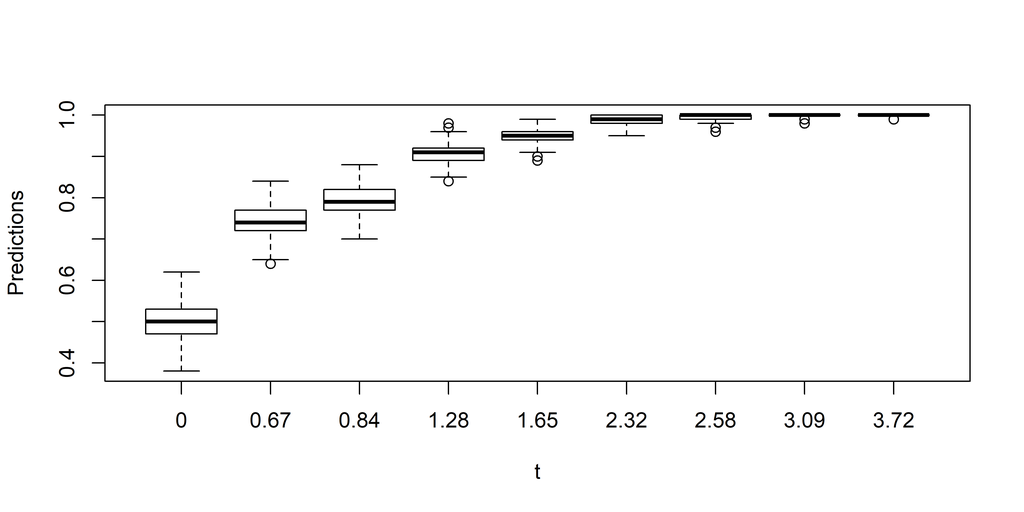

Figure 5.1: 100-run Predictions with 100 samples.

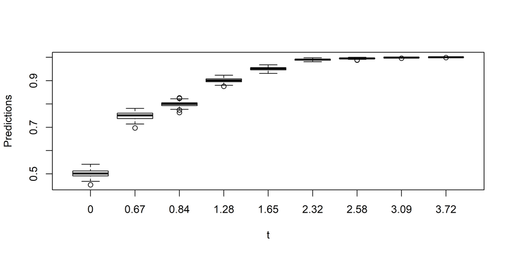

Figure 5.2: 100-run Predictions with 1000 samples

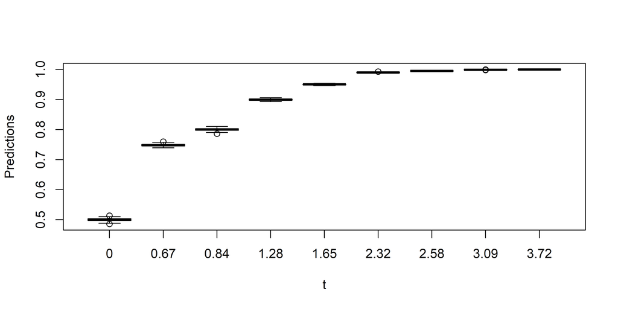

Figure 5.3: 100-run Predictions with 10000 samples

```r
boxplot(Pred_100 ~ t, data = final_data_100, xlab = "t",ylab = "Predictions")
```

If we would like to see box plots of bias for cases with different sample sizes, Figure 5.4, 5.5 and 5.6 are given as follow.

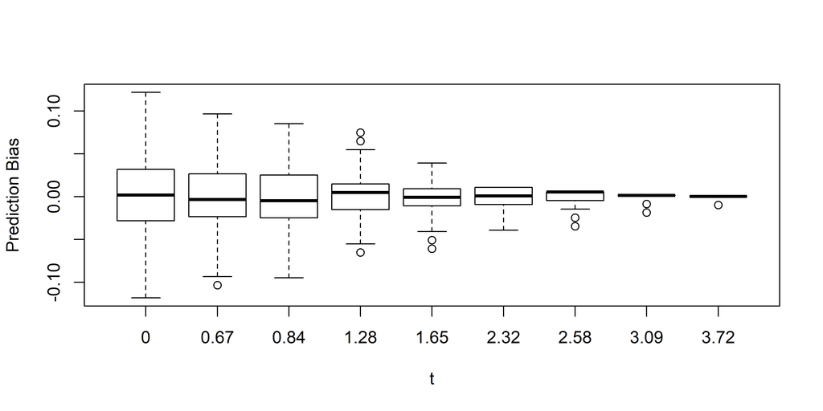

Figure 5.4: Bias of 100-run Predictions with 100 samples.

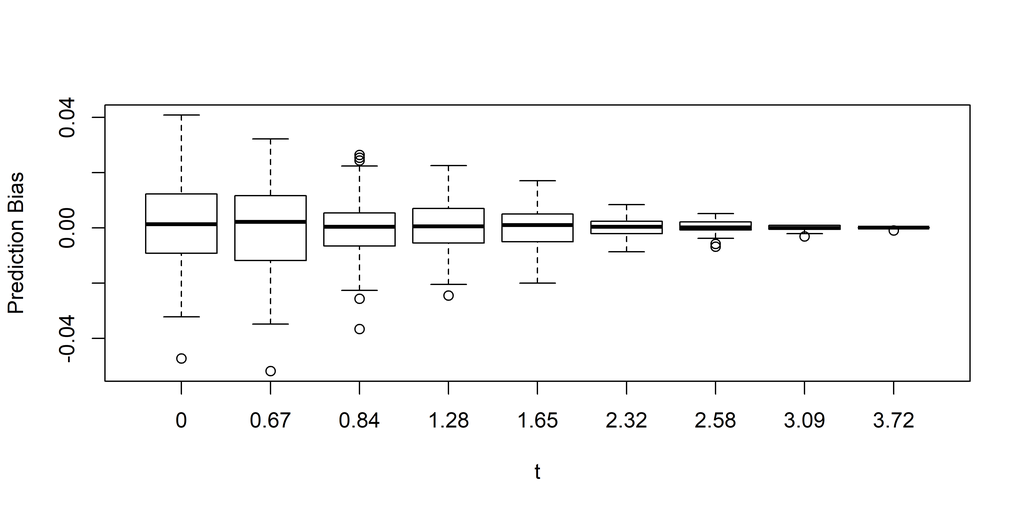

Figure 5.5: Bias of 100-run Predictions with 1000 samples.

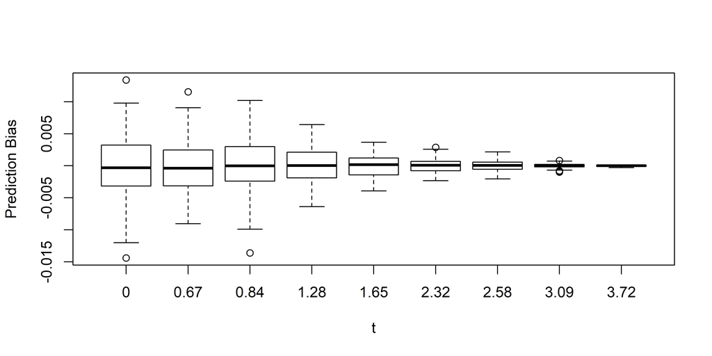

Figure 5.6: Bias of 100-run Predictions with 10000 samples.

Based on results, with increasing sample size, the predictions present smaller bias. If the algorithm works well, we could say more accurate approximation would be obtained.

# 6 Code Chunk

The code chunk of major calculation is given as follow,

```r
t <- c(0,0.67,0.84,1.28,1.65,2.32,2.58,3.09,3.72)
n <- c(100,1000,10000)

# true value
ture_Phi <- pnorm(t)

# Prediction function
Pred_Phi_100 <- function(x){
  y <- rnorm(100);
  m <- sum(y<=x);
  m/100
}

Pred_Phi_1000 <- function(x){
  y <- rnorm(1000);
  m <- sum(y<=x);
  m/1000
}

Pred_Phi_10000 <- function(x){
  y <- rnorm(10000);
  m <- sum(y<=x);
  m/10000
}

## One-time experiment
# try sapply function
Pred_1_100 <- sapply(t,Pred_Phi_100)
Pred_1_1000 <- sapply(t,Pred_Phi_1000)
Pred_1_10000 <- sapply(t,Pred_Phi_10000)
final_data_1 <- data.frame(t = t, `Ture Value`= ture_Phi, `n = 100` = Pred_1_100,
                           `n = 1000` = Pred_1_1000,
                           `n = 10000` = Pred_1_10000, stringsAsFactors = FALSE,
                           check.names = FALSE)

## 100-time experiment
# T <- matrix(rep(t,each = 100), nrow = 100)
T <- rep(t,each = 100)
# Ture_Phi <- matrix(rep(ture_Phi,each = 100), nrow = 100)
# n = 100
Pred_100_100 <- sapply(T,Pred_Phi_100)
Pred100_100 <- array(Pred_100_100,c(100,9)) #reshape

# n = 1000
Pred_100_1000 <- sapply(T,Pred_Phi_1000)
Pred100_1000 <- array(Pred_100_1000,c(100,9)) #reshape

# n = 10000
Pred_100_10000 <- sapply(T,Pred_Phi_10000)
Pred100_10000 <- array(Pred_100_10000,c(100,9)) #reshape

final_data_100 <- data.frame(t = T, Pred_100 = Pred_100_100, Pred_1000 = Pred_100_1000,
                             Pred_10000 = Pred_100_10000)

## get predictions' bias
# mean of predictions
mean100 <- apply(Pred100_100,2,mean)
mean1000 <- apply(Pred100_1000,2,mean)
mean10000 <- apply(Pred100_10000,2,mean)
Mean100 <- rep(mean100,each = 100)
Mean1000 <- rep(mean1000,each = 100)
Mean10000 <- rep(mean10000,each = 100)
# bias
bias100 <- Pred_100_100 - Mean100
bias1000 <- Pred_100_1000 - Mean1000
bias10000 <- Pred_100_10000 - Mean10000
final_data_bias <- data.frame(t = T, bias_100 = bias100, bias_1000 = bias1000,
                              bias_10000 = bias10000)
```

The chunk option `eval = FALSE` is set, in order to present the code without evaluation.

# 7 Summary

I approximated the integration accurately by Monte Carlo Methods. I used the template to report what I have done for this practise. I tried some functions and syntax of writing a *.Rmd* document. Overall, through this homework, I am getting familiar with R and RMarkdown.

# Acknowledgment

Thanks to Wenjie Wang’s template, which isavailable at GitHub repository *dslab-templates*: https://github.com/statds/dslab-templates. And thanks to all the other authors and contributors.

# Reference

[^1]: yuqian.liu@uconn.edu; Ph.D. student at Department of Mechanical Engineering, University of Connecticut.